# Customer Churn

Samer Alzaim

```r
data1 <- read.table("https://pengdsci.github.io/datasets/ChurnData/Customer-Chrn-dataset.txt",
                   header = TRUE, sep = ",", stringsAsFactors = FALSE)
```

# 1 Background

In this step, we will look at numeric variable and fit the model to predict this variable. the dat set has 2 numeric variables, Monthly_Charges and Total_Charges. We will use Monthy_Scharges as our res-ponder variable.

# 2 Fitting the Model

from the graph below, it seems that we only have 2 variables that contribute to the prediction of Monthly_Charges.

```r
# Set seed for reproducibility
set.seed(654321)

# Prepare features (X) and target (y)
X <- as.matrix(data1[, -12])  # Features (all columns except the target)
y <- data1$Monthly_Charges  # Ensure numeric

# Split the data into training and testing sets
train_index <- createDataPartition(y, p = 0.8, list = FALSE)
X_train <- X[train_index, ]
X_test <- X[-train_index, ]
y_train <- y[train_index]
y_test <- y[-train_index]

# Standardize the data (important for regularization)
preprocess_params <- preProcess(X_train, method = c("center", "scale"))
X_train <- predict(preprocess_params, X_train)
X_test <- predict(preprocess_params, X_test)

# Fit Linear Regression Models with Regularization
fit_lasso <- glmnet(X_train, y_train, alpha = 1)       # Lasso regression
fit_ridge <- glmnet(X_train, y_train, alpha = 0)       # Ridge regression
fit_elastic_net <- glmnet(X_train, y_train, alpha = 0.5) # Elastic net

# Cross-validation
cv_lasso <- cv.glmnet(X_train, y_train, alpha = 1)
cv_ridge <- cv.glmnet(X_train, y_train, alpha = 0)
cv_elastic_net <- cv.glmnet(X_train, y_train, alpha = 0.5)
```

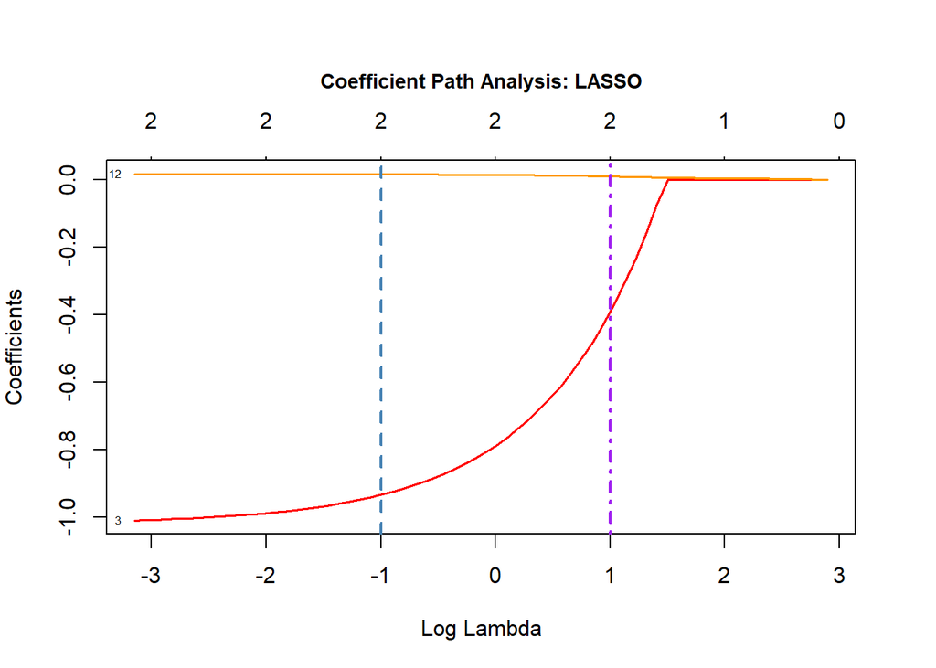

```r
par(mar=c(5,4,6,3))
# Plot coefficient path
plot(fit_lasso, xvar = "lambda", label = TRUE,
     lwd = 1.5,
     main = "Coefficient Path Analysis: LASSO",
     cex.main = 0.9,
     col = rainbow(10))
abline(v = 1, col = "purple", lty = 4, lwd = 2)
abline(v = -1, col = "steelblue", lty = 2, lwd = 2)
```

##RMSE Plot Looking a RMSE plot we can see that best lambda is between 1 and zero, consideing lower lmbda will not further improve the RMSE.

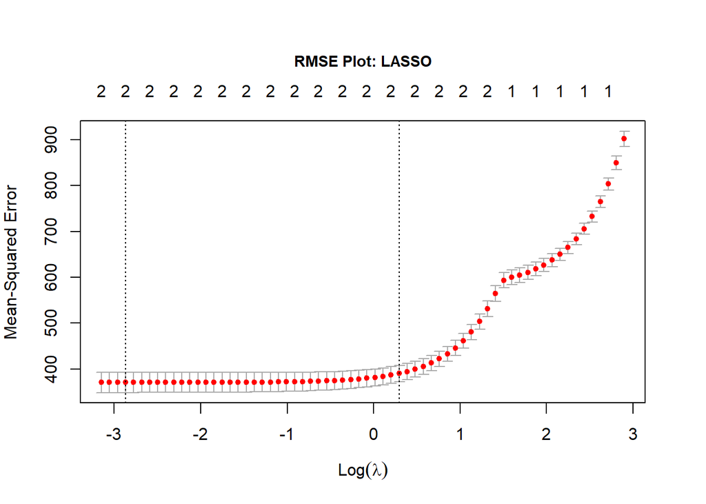

```r
par(mar=c(5,4,6,3))
##
plot(cv_lasso, main = "RMSE Plot: LASSO",
     cex.main = 0.9)
```